# Part II - Prosper Loan: Factors Affecting Borrowers and Investors

## by Banji R. Owabumoye

## Investigation Overview

> This project is based on [Prosper](https://www.prosper.com/). Prosper is an online loan company founded in the year 2005. The company offers a variety of resources people can use to try and improve their financial health, regardless of their financial situation.  
> The main objectives of this project are to consider factors affecting loan's outcome status, to examine determinant factors loan amount is based and examination of factors determinant to investors' decision.

## Dataset Overview

> The acquired Prosper loan dataset originally comprised 81 variables and 113,937 rows. After assessing and cleaning which included transforming of some variables, 26 variables and 83,520 rows were left for analysis.

## Likely Days Borrowers Could be Listed

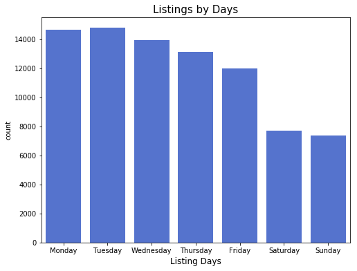

## Borrowers' Income Category

Income category or income range seems to be an important factor affecting loan's outcome status. Borrowers that are in the categories of 'Low' and 'Average' are more than other categories. Borrowers with 'No-income' are least considered followed by borrowers in 'Very-low' income category'. Borrowers that are in 'High' and Very-high' income categories are quite above average.

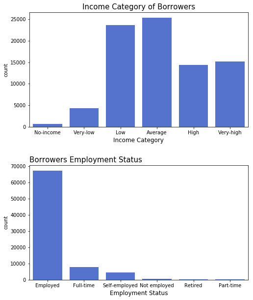

## Prosper Rating and Risk Score

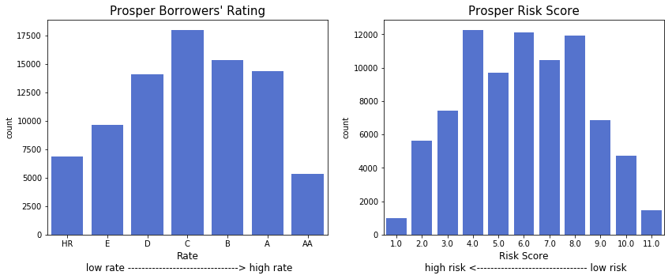

## Borrowers' Monthly Income

The log transformation used for plotting the monthly income chart revealed that most borrowers are earning around 5,000 dollars that is, between 2,000 dollars and 10,000 dollars. This income range is inline with 'Low' and 'Average income categories.

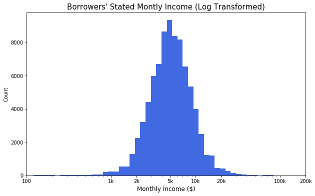

## Investors by Proper Score and Loan Original Amount

There is a positive relationship between Prosper Score and Investors. The higher the Prosper Score, the higher the number of investors. This means that investors have confidence in Prosper Score to take investment decisions. Likewisely, Investors and Loan Original Amount are positively correlated. The higher the loan amount the higher the number of investors that will fund the loan.

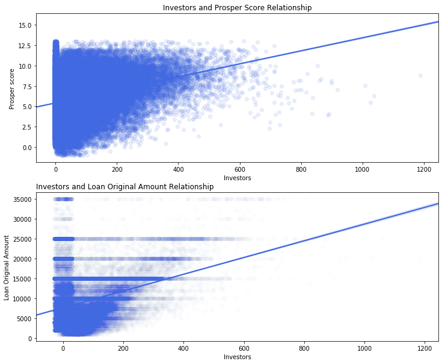

## Impact of Prosper Rate and Income Category on Investors' Decision

Findings between ProsperRating(Alpha) and Investors are quite insightful. The lowest rated borrowers (HR) hardly registered 1 investor solely taking the risk to invest in borrowers rated that so low. Most investors investing in borrowers rated so low are around 50 - 100 investors. Compared to borrowers rated E, D, C, B, A, and AA that have many sole investors that could take the risk of investing just because of ProsperRating. ProsperRating(Alpha) highly influence investors' decision.

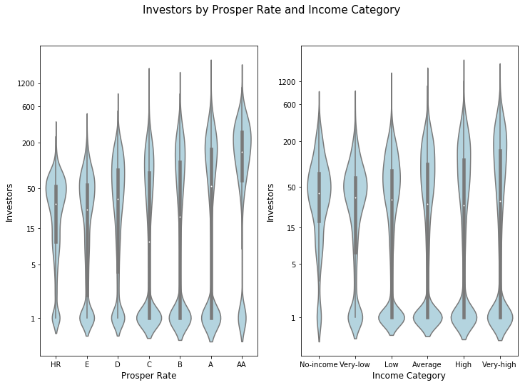

## How Prosper Rating Determines Loan Amount

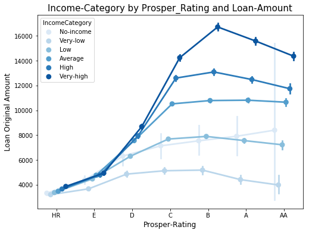

## Influence of Employment Status and Loan Amount on Loan Term

Borrowers in the employment status categories from 'Employed', 'Full-time', Self-employed', to 'Not employed' were mostly given loan around 5,000 dollars and these loans were short-term (12 months) and mid-term (36 months loan). Borrowers that are 'Retired', and 'Part-time' recorded no or little short-term loan. Long-term loans of 60 months around 10,000 dollars to 40,000 dollars were mostly offered to borrowers that are 'Employed' or/and 'Full-time'. This analysis has shown that employment status of borrowers has impact on amount of loan and loan term. combination of these features will affect loan outcome, amount of loan,and influence investors' decision on borrowers to invest on.

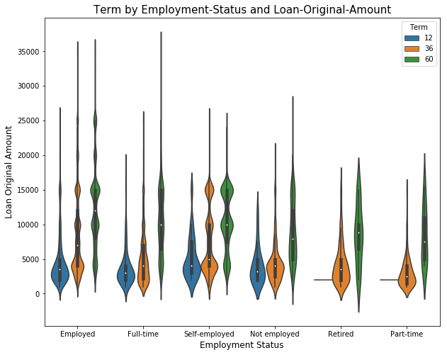